# (Pertemuan 02) Sintaks Dasar Python

Python Basic Syntax

Offline di Departemen Matematika

Author

Tim Dosen Praktikum Algoritma dan Pemrograman

Published

September 3, 2024

Kembali ke Mata Kuliah Praktikum Algoritma dan Pemrograman

3 September 2024 - Pertemuan 2

Materi Pembahasan:

1. Pengenalan ‘print’ dan Data Type
2. Operasi Integer dan Float
3. Operasi pada String
4. Variabel
5. Boolean
6. Perbandingan antara Variabel
7. Meminta ‘input’

Praktikum Algoritma dan Pemrograman PTA 2024-2025  
Departemen Matematika FMIPA Universitas Indonesia

There are three alternative types of tools for writing Python programs:

- a plain text editor
- an integrated development environment (IDE) with a text editor
- an IPython notebook

Recommendations:

- If you are a student a university where Windows is the dominating operating system, and you are a Windows user yourself, install Anaconda. Write and run Python programs in **Spyder**.
- If you are uncertain how much you will program with Python and primarily want to get a taste of Python programming first, access Python in the cloud, e.g., through the **Google Colab**.

## Pengenalan ‘print’ dan Data Type

```python
# Gunakan tanda pagar (#) untuk menulis komentar
print(5)  # Ini adalah komentar, Python akan mengabaikannya
print(10)
```

```
5
10
```

```python
#Sebagai calculator
5*0.6 - 0.5*9.81*0.6**2
```

```
1.2342
```

```python
#Pengenalan data type (int,float,string)
#integer
a = 5

#float
b = 3.14

#string
c = "Ayam"
print(a)
print(b)
print(c)
```

```
5
3.14
Ayam
```

```python
#print sekaligus
print(a,b,c)
```

```
5 3.14 Ayam
```

```python
#cek data type
print(type(a), type(b), type(c))
```

```
<class 'int'> <class 'float'> <class 'str'>
```

## Operasi Integer dan Float

```python
# Operasi dasar pada bilangan integer
x = 2
y = 3
print(x + y)    # Penjumlahan
print(x - y)    # Pengurangan
print(x % y)    # Modulo, sisa pembagian
print(x / y)    # Pembagian, hasil berupa float
print(type(x / y))  # Menampilkan tipe data hasil pembagian
print(x * y)    # Perkalian
print(x ** y)   # x pangkat y
print(y // x)   # Pembagian Floor, hasil pembagian dibulatkan ke bawah
```

```
5
-1
2
0.6666666666666666
<class 'float'>
6
8
1
```

```python
# Operasi dasar pada bilangan float
p = 6.14
q = 2.87
print(p + q)    # Penjumlahan
print(p - q)    # Pengurangan
print(p % q)    # Modulo, sisa pembagian
print(p / q)    # Pembagian
print(p * q)    # Perkalian
print(p ** q)   # Eksponensiasi, p pangkat q
print(p // q)   # Pembagian Floor, hasil pembagian dibulatkan ke bawah
print(round(p)) # Pembulatan angka float
print(round(q))
```

```
9.01
3.2699999999999996
0.39999999999999947
2.1393728222996513
17.6218
182.82821753613698
2.0
6
3
```

## Operasi pada String

```python
# Operasi penjumlahan pada string (penggabungan)
stringa = "Saya"
stringb = "makan"
print(stringa + stringb)  # Hasil penggabungan tanpa spasi
print(stringa + " " + stringb)  # Hasil penggabungan dengan spasi di antara kedua string
```

```
Sayamakan
Saya makan
```

```python
len(stringa)
```

```
4
```

```python
# Mengecek panjang (jumlah karakter) dari string
panjang_stringa = len(stringa)
print(panjang_stringa)  # Menampilkan panjang stringa
```

[output not shown]

```python
len(stringb)
```

```
5
```

```python
# Mengambil (slice) beberapa huruf dari string
print(stringa[0:1])   # Mengambil karakter pertama dari stringa
print(stringa[1:4])   # Mengambil karakter dari indeks 1 sampai 4 (5 melebihi batas, tidak menyebabkan error)

# Menggunakan indeks negatif untuk mengambil karakter dari akhir string
print(stringb[-1])    # Mengambil karakter terakhir dari stringb

# Mengambil karakter dari awal string hingga indeks tertentu
stringc = "saya makan nasi di warung"
print(stringc[:15])   # Mengambil karakter dari indeks 0 sampai 14

# Mengambil karakter dari indeks tertentu hingga akhir string
print(stringc[19:])   # Mengambil karakter dari indeks 19 hingga akhir
```

```
S
aya
n
saya makan nasi
warung
```

```python
# Mencari indeks terkecil dari karakter tertentu dalam string
print(stringb)
print(stringb.index("k"))    # Mencari indeks pertama dari huruf 'k' dalam stringb

# Mencari indeks dari substring
print(stringb.index("aka"))  # Mencari indeks awal dari substring 'aka' dalam stringb

# Mencari indeks spasi dalam string
stringd = "Ayam berkokok"
print(stringd.index(" "))    # Mencari indeks pertama dari spasi dalam stringd
```

```
makan
2
1
4
```

```python
# Menghitung jumlah kemunculan karakter tertentu dalam string
print(stringb)
print(stringb.count("a"))  # Menghitung berapa kali huruf 'a' muncul dalam stringb

# Menghitung jumlah kemunculan substring dalam string
stringe = "saya buaya daya pepaya"
print(stringe.count("aya"))  # Menghitung berapa kali substring 'aya' muncul dalam stringe
```

```
makan
2
4
```

## Variabel

```python
x = 5
x = x+2
print(x)
```

```
7
```

```python
x = x/2
print(x)

x = x**2
print(x)

x = x%3
print(x)
```

```
3.5
12.25
0.25
```

```python
# Notasi singkat untuk operasi penjumlahan dan perkalian
x += 4   # Sama dengan x = x + 4
print(x)

x *= 2   # Sama dengan x = x * 2
print(x)
```

```
4.25
8.5
```

**Alamat Memori**: ID yang dikembalikan oleh id() biasanya merupakan alamat memori tempat objek tersebut disimpan. Ini penting ketika Anda ingin memahami bagaimana Python menangani referensi objek dalam memori.

**Unik untuk Setiap Objek**: Dua objek berbeda (meskipun memiliki nilai yang sama) akan memiliki ID yang berbeda. Namun, jika dua variabel merujuk ke objek yang sama, mereka akan memiliki ID yang sama.

```python
# Mengecek ID (alamat memori) dari variabel
a = 4
print(id(a))  # Menampilkan ID unik dari variabel 'a'
```

```
137124125065552
```

```python
a = 4
b = a
print(id(a),id(b))
```

```
137124125065552 137124125065552
```

```python
a = 4
b = a
a = a + 2
print(id(a), id(b))  # ID 'a' berubah setelah nilainya diubah, sementara ID 'b' tetap sama
print(a)  # 'a' sekarang bernilai 6
print(b)  # 'b' tetap bernilai 4
```

```
137124125065616 137124125065552
6
4
```

```python
#variabel pada string
print(stringa)
print(stringb)
```

```
Saya
makan
```

```python
# Menggabungkan dua string
stringa = stringa + stringb  # stringa sekarang menjadi hasil penggabungan stringa sebelumnya dan stringb
print(stringa)  # Menampilkan hasil penggabungan dari stringa dan stringb
```

```
Sayamakan
```

```python
stringa = "Saya"
```

```python
# Untuk memperbaiki stringa dengan menambahkan spasi di antara dua string,
# perlu menambahkan spasi saat penggabungan
stringa = stringa + " " + stringb  # Menambahkan spasi antara stringa dan stringb saat penggabungan
print(stringa)  # Menampilkan hasil penggabungan yang sudah dipisahkan dengan spasi
```

```
Saya makan
```

## Boolean

```python
# Tipe data boolean
# Boolean hanya memiliki dua nilai, yaitu:
True   # Bernilai benar
False  # Bernilai salah
```

```
False
```

```python
# Operasi logika pada boolean: and, or, not
print(True and False)  # and: Menghasilkan True jika kedua operand True, jika tidak maka False
print(True or False)   # or: Menghasilkan True jika salah satu atau kedua operand True
print(not True)        # not: Membalik nilai boolean, True menjadi False dan sebaliknya
```

```
False
True
False
```

## Perbandingan antara Variabel

```python
#bilangan bulat
x = 4
y = 3
x > y
```

```
True
```

```python
print(x < y)
print(x == y)
print(x!= y) #tidak sama dengan
```

```
False
False
True
```

```python
#float
a = 2.17
b = 2.17
print(a<b)
print(a<=b)
print(a>b)
print(a>=b)
print(a==b)
print(a!=b)
```

```
False
True
False
True
True
False
```

```python
#string
stringp = "saya"
stringq = "makan"
stringr = "SAYA"
strings = "saya"
stringp == stringq
```

```
False
```

```python
print(stringp == stringr)
print(stringp == strings)
print(stringp != stringq)
```

```
False
True
True
```

```python
#Mengecek apakah string a substring dari string b
stringp = "saya pepaya"
stringq = "aya p"
stringq in stringp
```

```
True
```

```python
"makan" in stringp
```

```
False
```

## Meminta input

```python
#integer
x = int(input("Masukan input integer :"))
x = x+1
print(x)
```

```
Masukan input integer :5
6
```

```python
#float
y = float(input( "masukan bilangan real :"))
y = y/2
print(y)
```

```
masukan bilangan real :2.67
1.335
```

```python
#string
z = str(input("Masukan nama anda:"))
print("Halo "+ z)
```

```
Masukan nama anda:kucing
Halo kucing
```

# Latihan

Buatlah program untuk implementasi algoritma berikut.

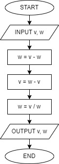

latihan.jpg

Jika diberikan input v = 4 dan w = 6, maka output yang dihasilkan adalah…

```python
v = int(input("Masukan input integer :"))
w = int(input("Masukan input integer :"))
# v = 4
#w = 6
w = v - w
v = w - v
w = v/w
print(v, w)
```

```
Masukan input integer :4
Masukan input integer :6
-6 3.0
```